# INM430 - House Price Prediction by Using Regression technique

## Student Name: Shengqiang Fan

# Analytycal Process

```python
%matplotlib inline
import pandas as pd
import numpy as np
import matplotlib.pyplot as plt
import seaborn as sns
from sklearn.linear_model import Lasso,LassoCV
from sklearn.model_selection import cross_val_score
from xgboost.sklearn import XGBRegressor
from sklearn.model_selection import GridSearchCV
plt.style.use('ggplot')
```

## 1 Data Collection and Preparation

## 1.1 Data collection and data type transformation

```python
traindata = pd.read_csv('train.csv')
testdata = pd.read_csv('test.csv')
```

```python
#print(traindata.info())
#print(testdata.info())
```

```python
traindata.head()
```

|  | Id | MSSubClass | MSZoning | LotFrontage | LotArea | Street | Alley | LotShape | LandContour | Utilities | ... | PoolArea | PoolQC | Fence | MiscFeature | MiscVal | MoSold | YrSold | SaleType | SaleCondition | SalePrice |
| --- | --- | --- | --- | --- | --- | --- | --- | --- | --- | --- | --- | --- | --- | --- | --- | --- | --- | --- | --- | --- | --- |
| 0 | 1 | 60 | RL | 65.0 | 8450 | Pave | NaN | Reg | Lvl | AllPub | ... | 0 | NaN | NaN | NaN | 0 | 2 | 2008 | WD | Normal | 208500 |
| 1 | 2 | 20 | RL | 80.0 | 9600 | Pave | NaN | Reg | Lvl | AllPub | ... | 0 | NaN | NaN | NaN | 0 | 5 | 2007 | WD | Normal | 181500 |
| 2 | 3 | 60 | RL | 68.0 | 11250 | Pave | NaN | IR1 | Lvl | AllPub | ... | 0 | NaN | NaN | NaN | 0 | 9 | 2008 | WD | Normal | 223500 |
| 3 | 4 | 70 | RL | 60.0 | 9550 | Pave | NaN | IR1 | Lvl | AllPub | ... | 0 | NaN | NaN | NaN | 0 | 2 | 2006 | WD | Abnorml | 140000 |
| 4 | 5 | 60 | RL | 84.0 | 14260 | Pave | NaN | IR1 | Lvl | AllPub | ... | 0 | NaN | NaN | NaN | 0 | 12 | 2008 | WD | Normal | 250000 |

5 rows × 81 columns

```python
train_features = traindata.loc[:,'MSSubClass':'SaleCondition']
```

```python
test_features = testdata.loc[:,'MSSubClass':'SaleCondition']
```

```python
train_features['MSSubClass'] = train_features['MSSubClass'].astype(str)
train_features['OverallQual'] = train_features['OverallQual'].astype(str)
train_features['OverallCond'] = train_features['OverallCond'].astype(str)
train_features['TotRmsAbvGrd'] = train_features['TotRmsAbvGrd'].astype(str)
train_features['KitchenAbvGr'] = train_features['KitchenAbvGr'].astype(str)
train_features['BedroomAbvGr'] = train_features['BedroomAbvGr'].astype(str)
train_features['GarageCars'] = train_features['GarageCars'].astype(str)
train_features['Fireplaces'] = train_features['Fireplaces'].astype(str)
train_features['FullBath'] = train_features['FullBath'].astype(str)
train_features['HalfBath'] = train_features['HalfBath'].astype(str)
train_features['BsmtHalfBath'] = train_features['BsmtHalfBath'].astype(str)
train_features['BsmtFullBath'] = train_features['BsmtFullBath'].astype(str)
```

```python
test_features['MSSubClass'] = test_features['MSSubClass'].astype(str)
test_features['OverallQual'] = test_features['OverallQual'].astype(str)
test_features['OverallCond'] = test_features['OverallCond'].astype(str)
test_features['TotRmsAbvGrd'] = test_features['TotRmsAbvGrd'].astype(str)
test_features['KitchenAbvGr'] = test_features['KitchenAbvGr'].astype(str)
test_features['BedroomAbvGr'] = test_features['BedroomAbvGr'].astype(str)
test_features['GarageCars'] = test_features['GarageCars'].astype(str)
test_features['Fireplaces'] = test_features['Fireplaces'].astype(str)
test_features['FullBath'] = test_features['FullBath'].astype(str)
test_features['HalfBath'] = test_features['HalfBath'].astype(str)
test_features['BsmtHalfBath'] = test_features['BsmtHalfBath'].astype(str)
test_features['BsmtFullBath'] = test_features['BsmtFullBath'].astype(str)
```

```python
continu = [f for f in train_features.columns if train_features.dtypes[f] != 'object']
discrete = [f for f in train_features.columns if train_features.dtypes[f] == 'object']
print("continu: {}, discrete: {}" .format (len(continu),len(discrete)))
```

```
continu: 24, discrete: 55
```

## 1.2 Data Cleaning / Missing data

```python
missing = train_features.isnull().sum()
missing[missing > 0].sort_values(ascending=False)
```

```
PoolQC          1453
MiscFeature     1406
Alley           1369
Fence           1179
FireplaceQu      690
LotFrontage      259
GarageYrBlt       81
GarageType        81
GarageFinish      81
GarageQual        81
GarageCond        81
BsmtFinType2      38
BsmtExposure      38
BsmtFinType1      37
BsmtCond          37
BsmtQual          37
MasVnrArea         8
MasVnrType         8
Electrical         1
dtype: int64
```

Some features have lots of missing data, but they are treated differently based on its inherent characteristics. For example, although missing data appears in PoolQC (pool quality), but it might represent for no pool accompany to corresponding house. And for continuous feature, mean value is used for replacing missing data

```python
nacols = ["PoolQC" , "MiscFeature", "Alley", "Fence", "FireplaceQu", "GarageQual", "GarageCond", "GarageFinish", "GarageYrBlt", "GarageType", "BsmtExposure", "BsmtCond", "BsmtQual", "BsmtFinType2", "BsmtFinType1", "MasVnrType"]
```

```python
for a in nacols:
    train_features[a].fillna('None', inplace=True)
```

```python
zerocols=["MasVnrArea", "BsmtUnfSF", "TotalBsmtSF", "GarageCars", "BsmtFinSF2", "BsmtFinSF1", "GarageArea"]
```

```python
for b in zerocols:
    train_features[b].fillna(0,inplace=True)
```

```python
train_features['LotFrontage'].fillna((train_features['LotFrontage'].mean()), inplace=True)
```

```python
pd.value_counts(test_features.Electrical)
```

```
SBrkr    1337
FuseA      94
FuseF      23
FuseP       5
Name: Electrical, dtype: int64
```

```python
train_features['Electrical'].fillna('SBrkr', inplace=True)
```

The folowing part is process for test data. Firstly, same procedure from train set is compucted for test set

```python
for a in nacols:
    test_features[a].fillna('None', inplace=True)
```

```python
for b in zerocols:
    test_features[b].fillna(0,inplace=True)
```

```python
test_features['LotFrontage'].fillna((test_features['LotFrontage'].mean()), inplace=True)
```

```python
train_features['Electrical'].fillna('SBrkr', inplace=True)
```

```python
missing_test = test_features.isnull().sum()
missing_test[missing_test > 0].sort_values(ascending=False)
```

```
MSZoning       4
Functional     2
Utilities      2
SaleType       1
KitchenQual    1
Exterior2nd    1
Exterior1st    1
dtype: int64
```

```python
pd.value_counts(test_features.MSZoning)
```

```
RL         1114
RM          242
FV           74
C (all)      15
RH           10
Name: MSZoning, dtype: int64
```

```python
test_features['MSZoning'].fillna('RL', inplace=True)
```

```python
pd.value_counts(test_features.Functional)
```

```
Typ     1357
Min2      36
Min1      34
Mod       20
Maj1       5
Maj2       4
Sev        1
Name: Functional, dtype: int64
```

```python
test_features['Functional'].fillna('Typ', inplace=True)
```

```python
pd.value_counts(test_features.Utilities)
```

```
AllPub    1457
Name: Utilities, dtype: int64
```

```python
test_features['Utilities'].fillna('AllPub', inplace=True)
```

```python
pd.value_counts(test_features.SaleType)
```

```
WD       1258
New       117
COD        44
ConLD      17
CWD         8
Oth         4
ConLI       4
ConLw       3
Con         3
Name: SaleType, dtype: int64
```

```python
test_features['SaleType'].fillna('WD', inplace=True)
```

```python
pd.value_counts(test_features.KitchenQual)
```

```
TA    757
Gd    565
Ex    105
Fa     31
Name: KitchenQual, dtype: int64
```

```python
test_features['KitchenQual'].fillna('TA', inplace=True)
```

```python
pd.value_counts(test_features.Exterior2nd)
```

```
VinylSd    510
MetalSd    233
HdBoard    199
Wd Sdng    194
Plywood    128
CmentBd     66
Wd Shng     43
BrkFace     22
Stucco      21
AsbShng     18
Brk Cmn     15
ImStucc      5
CBlock       2
AsphShn      1
Stone        1
Name: Exterior2nd, dtype: int64
```

```python
test_features['Exterior2nd'].fillna('VinylSd', inplace=True)
```

```python
pd.value_counts(test_features.Exterior1st)
```

```
VinylSd    510
MetalSd    230
HdBoard    220
Wd Sdng    205
Plywood    113
CemntBd     65
BrkFace     37
WdShing     30
AsbShng     24
Stucco      18
BrkComm      4
AsphShn      1
CBlock       1
Name: Exterior1st, dtype: int64
```

```python
test_features['Exterior1st'].fillna('VinylSd', inplace=True)
```

```python
missing_test_r = test_features.isnull().sum()
missing_test_r[missing_test_r > 0].sort_values(ascending=False)
```

```
Series([], dtype: int64)
```

So far, there is no missing values in both train and test set.

# 2 Data Exploration Analysis

## 2.1 Box plot for categorical features --- find some trends

```python
contitu_feats = train_features.dtypes[train_features.dtypes!="object"].index
discrete_feats = train_features.dtypes[train_features.dtypes=="object"].index
contitu_feats
```

```
Index(['LotFrontage', 'LotArea', 'YearBuilt', 'YearRemodAdd', 'MasVnrArea',
       'BsmtFinSF1', 'BsmtFinSF2', 'BsmtUnfSF', 'TotalBsmtSF', '1stFlrSF',
       '2ndFlrSF', 'LowQualFinSF', 'GrLivArea', 'GarageArea', 'WoodDeckSF',
       'OpenPorchSF', 'EnclosedPorch', '3SsnPorch', 'ScreenPorch', 'PoolArea',
       'MiscVal', 'MoSold', 'YrSold'],
      dtype='object')
```

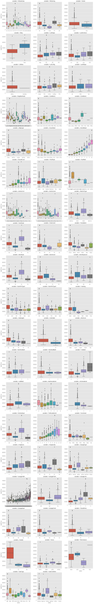

```python
def boxplot(x,y,**kwargs):
     sns.boxplot(x=x,y=y)
f = pd.melt(traindata,id_vars=['SalePrice'],value_vars=discrete_feats)
g = sns.FacetGrid(f,col='variable',col_wrap=3,sharex=False,sharey=False,height=5)
g = g.map(boxplot,"value","SalePrice")
```

box plots are used especially for discrete data groups. It is obvious that Overall Quality, Overall Condition, LotShape, Alley, HeatingQC, TotRmsAbvGrd, FirePlaces, GarageYrBlt and GarageCars have positive relationship to Sale Price. In terms of other discrete features, low relationship founded based on box plots such as Land Slope and Roof Style. In addition, another interesting trend is that most of abnormal sale price value are above upper quartile rather than below lower quartile. Which indicates that the real estate developer always win price game with individual investor/buyer to sale their house above average market value.

## 2.2 Scatter plot for numerical features --- find outliers and delete them

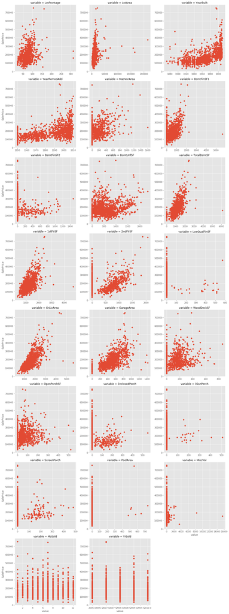

```python
f = pd.melt(traindata, id_vars=['SalePrice'],value_vars=contitu_feats)
g = sns.FacetGrid(f,col='variable',col_wrap=3,sharex=False,sharey=False,height=5)
g = g.map(plt.scatter,"value","SalePrice")
```

Scatter plots are used for continuous data groups. It is evidence to say that sale price is proportional to the increase of GrLivArea (above ground living area square feet), TotalBsmtSF (total square feet of basement area), YearBuilt, YearRemodAdd, BsmtFinSF1, 1stFlrSF, 2ndFlrSF and GarageArea. Moreover, for feature which has strong relationship with sale price, outliers can also be pointed easily. The point which is not in the reasonable trend range area is treated as outlier. For instance, two points at right bottom corner in Sale Price against GrLivArea and one point at right bottom corner in figure Sale Price against TotalBsmtSF. Process for dropping outliers is shown below. Except features discussed above, no evidence can prove their relationship with sale price based on scatter plots, such as MasVnrArea (Masonry veneer area in square feet) and BsmtUnfSF (Unfinished square feet of basement area).

```python
outlier_no = []
```

```python
traindata.sort_values(by = 'LotFrontage', ascending = False)[:2][['Id','LotFrontage','SalePrice']]
```

|  | Id | LotFrontage | SalePrice |
| --- | --- | --- | --- |
| 1298 | 1299 | 313.0 | 160000 |
| 934 | 935 | 313.0 | 242000 |

```python
outlier_no.append(1299)
outlier_no.append(935)
```

```python
traindata.sort_values(by = 'LotArea', ascending = False)[:3][['Id','LotArea','SalePrice']]
```

|  | Id | LotArea | SalePrice |
| --- | --- | --- | --- |
| 313 | 314 | 215245 | 375000 |
| 335 | 336 | 164660 | 228950 |
| 249 | 250 | 159000 | 277000 |

```python
outlier_no.append(314)
outlier_no.append(336)
outlier_no.append(250)
```

```python
traindata.sort_values(by = 'BsmtFinSF1', ascending = False)[:1][['Id','BsmtFinSF1','SalePrice']]
```

|  | Id | BsmtFinSF1 | SalePrice |
| --- | --- | --- | --- |
| 1298 | 1299 | 5644 | 160000 |

```python
outlier_no.append(1299)
outlier_no.append(524)
```

```python
traindata.sort_values(by = 'BsmtFinSF2', ascending = False)[:1][['Id','BsmtFinSF2','SalePrice']]
```

|  | Id | BsmtFinSF2 | SalePrice |
| --- | --- | --- | --- |
| 322 | 323 | 1474 | 301000 |

```python
traindata.sort_values(by = 'TotalBsmtSF', ascending = False)[:1][['Id','TotalBsmtSF','SalePrice']]
```

|  | Id | TotalBsmtSF | SalePrice |
| --- | --- | --- | --- |
| 1298 | 1299 | 6110 | 160000 |

```python
outlier_no.append(1299)
```

```python
traindata.sort_values(by = '1stFlrSF', ascending = False)[:1][['Id','1stFlrSF','SalePrice']]
```

|  | Id | 1stFlrSF | SalePrice |
| --- | --- | --- | --- |
| 1298 | 1299 | 4692 | 160000 |

```python
outlier_no.append(1299)
```

```python
traindata.sort_values(by = 'LowQualFinSF', ascending = False)[:1][['Id','LowQualFinSF','SalePrice']]
```

|  | Id | LowQualFinSF | SalePrice |
| --- | --- | --- | --- |
| 185 | 186 | 572 | 475000 |

```python
outlier_no.append(186)
```

```python
traindata.sort_values(by = 'GrLivArea', ascending = False)[:2][['Id','GrLivArea','SalePrice']]
```

|  | Id | GrLivArea | SalePrice |
| --- | --- | --- | --- |
| 1298 | 1299 | 5642 | 160000 |
| 523 | 524 | 4676 | 184750 |

```python
outlier_no.append(1299)
outlier_no.append(524)
```

```python
outlier_no = np.unique(outlier_no)
outlier_no
```

```
array([ 186,  250,  314,  336,  524,  935, 1299])
```

```python
train_features = train_features.drop(outlier_no)
```

```python
traindata = traindata.drop(outlier_no)
```

## 2.3 Heatmap (pearson & spearman)

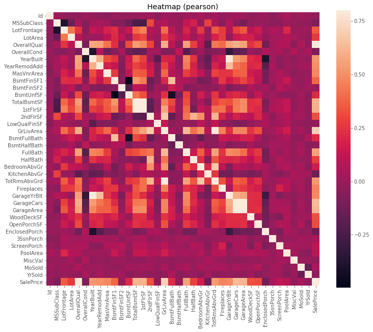

```python
plt.figure(figsize=(12,10))
corr_pearson = traindata.corr(method='pearson')
sns.heatmap(corr_pearson,vmax=0.8, square=True)
plt.title('Heatmap (pearson)')
plt.show()
```

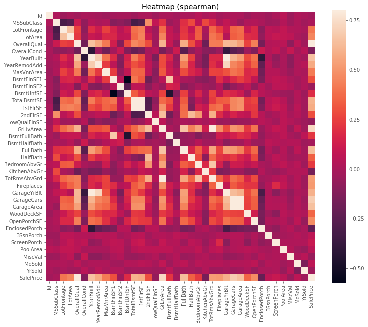

```python
plt.figure(figsize=(12,10))
corr_spearman = traindata.corr(method='spearman')
sns.heatmap(corr_spearman,vmax=0.8, square=True)
plt.title('Heatmap (spearman)')
plt.show()
```

Two heatmaps are generated to show the relationship between sale price and features and correlations among features, which is based on pearson method and spearman method respectively. Same color scheme is used for both heatmap, lighter color indicates stronger relationship and darker color shows weak correlation. In terms of relationship between sale price and each feature, both heatmaps highlight OverallQual, YearBuilt, ToatlBsmtSF, 1stFlrSF, GrLiveArea, FullBath, TotRmsAbvGrd, GarageCars and GarageArea. Thus, these highlighted features are very important for further prediction. With respect to correlation among features, there two areas with very light color, which are TotalBsmtSF against1stFlrSF and GarageCars against GarageArea. In other words, TotalBsmtSF (Total square feet of basement area) has a high correlation with 1stFlrSF (First Floor square feet), therefore, one of these two features can be dropped in order to avoid multicollinearity problem.

## 2.4 SalePrice distribution

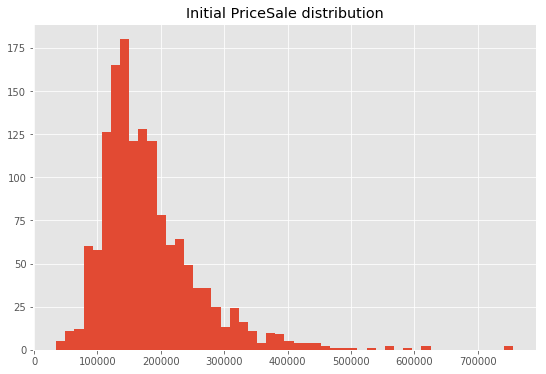

```python
plt.figure(figsize=(9,6))
plt.title('Initial PriceSale distribution')
plt.hist(traindata.SalePrice,bins=50)
plt.show()
```

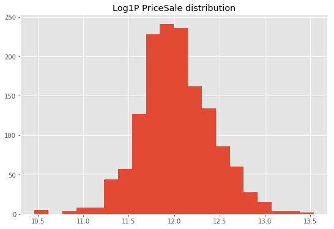

```python
log_SalePrice = np.log1p(traindata.SalePrice)
plt.figure(figsize=(9,6))
plt.title('Log1P PriceSale distribution')
plt.hist(log_SalePrice,bins=20)
plt.show()
```

# 3 Modelling and prediction

## 3.1 Preprocess before modelling

Normalization for continuous data (z-score normalization)

```python
continu_feats_means = train_features.loc[:,contitu_feats].mean()
continu_feats_std = train_features.loc[:, contitu_feats].std()
train_features.loc[:, contitu_feats] = (train_features.loc[:, contitu_feats] - continu_feats_means) / continu_feats_std
```

```python
test_continu_feats_means = test_features.loc[:,contitu_feats].mean()
test_continu_feats_std = test_features.loc[:, contitu_feats].std()
test_features.loc[:, contitu_feats] = (test_features.loc[:, contitu_feats] - test_continu_feats_means) / test_continu_feats_std
```

One-Hot Encoding (dummy variable) for discrete data

```python
full=pd.concat([train_features,test_features], ignore_index=True,sort=False)
```

```python
transformed_full = pd.get_dummies(full, dummy_na=True)
```

```python
num_train = train_features.shape[0]
```

```python
transformed_traindata = transformed_full[:num_train]
```

```python
transformed_testdata = transformed_full[num_train:]
```

```python
X_train = transformed_traindata.values
X_test = transformed_testdata.values
y_train = log_SalePrice
```

## 3.2 Lasso algorithm (without new features added)

Firsly, scoring method is defined as rmse followed by kaggle spefication.

```python
def rmse_cv(model):
    rmse= np.sqrt(-cross_val_score(model, X_train, y_train, scoring="neg_mean_squared_error", cv = 5))
    return(rmse)
```

Using grid search for finding best hyperparameter alpha

```python
alphas = np.logspace(-4, -2, 100)
cv_lasso = []
coefs = []
for alpha in alphas:
    model = Lasso(alpha = alpha,max_iter=5000)
    model.fit(X_train,y_train)
    cv_lasso.append(rmse_cv(model).mean())
    coefs.append(model.coef_)
```

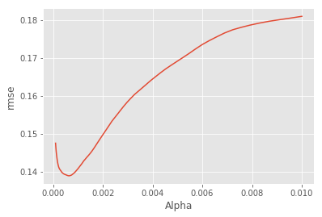

```python
cv_lasso = pd.Series(cv_lasso, index = alphas)
plt.plot(cv_lasso)
plt.xlabel("Alpha")
plt.ylabel("rmse")
```

```python
print(cv_lasso.min(), cv_lasso.idxmin())
```

```
0.13892254798485654 0.0006428073117284319
```

Hence, best hyperparameter alpha is chosen as 0.00064 for further modelling

```python
model = Lasso(alpha = 0.00064,max_iter=5000)
model.fit(X_train,y_train)
```

```
Lasso(alpha=0.00064, copy_X=True, fit_intercept=True, max_iter=5000,
   normalize=False, positive=False, precompute=False, random_state=None,
   selection='cyclic', tol=0.0001, warm_start=False)
```

```python
rmse_cv(model).mean()
```

```
0.13892221624145054
```

It is the 5-fold cross validation score.

Then try to find out coefficient of each features in lasso

```python
coef = pd.Series(model.coef_, index = transformed_traindata.columns)
```

```python
print("Lasso picked " + str(sum(coef != 0)) + " variables and eliminated the other " +  str(sum(coef == 0)) + " variables")
```

```
Lasso picked 141 variables and eliminated the other 410 variables
```

```python
imp_coef = pd.concat([coef.sort_values().head(15),
                     coef.sort_values().tail(15)])
```

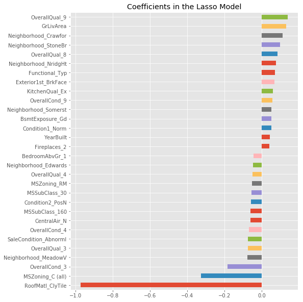

```python
plt.rcParams['figure.figsize'] = (8.0, 10.0)
imp_coef.plot(kind = "barh")
plt.title("Coefficients in the Lasso Model")
```

As we can see, Lasso gives higher weight to Overall Quali_9, GrLivArea, Neighborhood etc.

Then make prediction for test data and check the score from Kaggle

```python
lasso_predict = model.predict(X_test)
```

```python
lasso_predict_decode = np.expm1(lasso_predict)
lasso_predict_decode
```

```
array([126485.65591663, 161084.22298458, 191233.40078896, ...,
       170641.15163507, 124182.43572377, 226294.55799227])
```

```python
# Create a new dataframe with only the columns Kaggle wants from the dataset.
submission1 = pd.DataFrame({
        "Id": testdata['Id'],
        "SalePrice": lasso_predict_decode
    })
submission1.to_csv('submission1.csv', index=False)
```

kaggle scores for lasso (without new feature added) is 0.13872

## 3.3 Gradient boosting (without new features added)

As scoring method is already defined before, we can just start hyperparameter tuning for gradient boosting

```python
xg_model = XGBRegressor(n_estimators=100, seed = 1234)
param_dict = {'max_depth': [3,4,5],
              'min_child_weight': [2,3,4],
              'learning_rate': [0.05, 0.1,0.15],
              'gamma': [0.0, 0.1, 0.2]
}

grid_search = GridSearchCV(xg_model, param_dict,cv=5)
grid_search.fit(X_train, y_train)
display(grid_search.best_params_)
```

```
{'gamma': 0.0, 'learning_rate': 0.15, 'max_depth': 4, 'min_child_weight': 3}
```

Hyperparameter is chosen as gamma=0, learning rate = 0.15, max_depth = 4, min_child_weight = 3

```python
xg_model = XGBRegressor(n_estimators = 1000,
                        learning_rate = 0.15,
                        max_depth = 4,
                        min_child_weight = 3,
                        gamma = 0,
                        seed = 1234)
xg_model.fit(X_train, y_train)
print("xgb_cross_validation: ",rmse_cv(xg_model).mean())
```

```
xgb_cross_validation:  0.12829832920661094
```

Also make predictions for test set and check the scores from Kaggle

```python
xgb_predict = xg_model.predict(X_test)
```

```python
xgb_predict_decode = np.expm1(xgb_predict)
xgb_predict_decode
```

```
array([135025.67 , 163993.22 , 195590.67 , ..., 142682.8  , 119007.555,
       196344.4  ], dtype=float32)
```

```python
submission2 = pd.DataFrame({
        "Id": testdata['Id'],
        "SalePrice": xgb_predict_decode
    })
submission2.to_csv('submission2.csv', index=False)
```

kaggle scores for gradient boosting (without new feature added) is 0.14577

Then, feature importance from gradient boosting will be plotted in order to help to do feature selection afterwards.

```python
indices_xgb = np.argsort(xg_model.feature_importances_)[::-1]
```

```python
importance_gxb = xg_model.feature_importances_
```

```python
columnNames = np.asarray(transformed_traindata.columns.values)
```

```python
columnName_index = []
for i in range(20):
    columnName_index.append(columnNames[indices_xgb[i]])
```

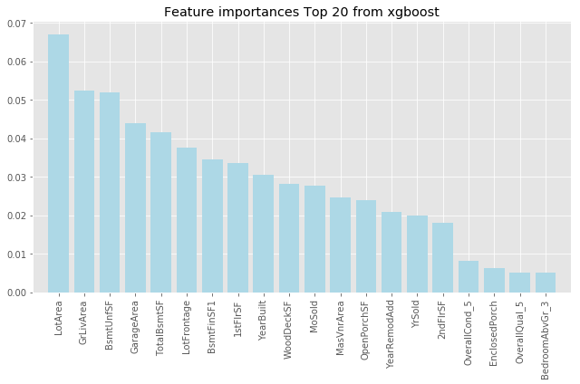

```python
plt.figure(figsize=(9,6))
plt.title("Feature importances Top 20 from xgboost")
plt.bar(range(20), importance_gxb[indices_xgb[:20]],
       color="lightblue", align="center")
plt.xticks(range(20),columnName_index, rotation=90)
plt.xlim([-1, 20])
plt.tight_layout()
plt.show()
```

As we can see, gradient boosting shows features such as LotArea, GreLivArea BsmtUnfSF .. are very important.

## 3.4 Add new features based on previous analysis and redo prediction process

10 more features are added based on the highlighted features from above plotting. For example, one new feature is overall quality * GreLivArea, another is Overall Quality + Overall Condition. And then based on 10 more added features, lasso and gradient boosting regression are conducted again to compare performance of sale price prediction.

```python
add_feature_full = full
```

```python
add_feature_full.shape
```

```
(2912, 79)
```

```python
transformed_full.shape
```

```
(2912, 551)
```

```python
add_feature_full['OverallQual'] = pd.to_numeric(add_feature_full['OverallQual'])
add_feature_full['OverallCond'] = pd.to_numeric(add_feature_full['OverallCond'])
add_feature_full['FullBath'] = pd.to_numeric(add_feature_full['FullBath'])
add_feature_full['HalfBath'] = pd.to_numeric(add_feature_full['HalfBath'])
```

```python
add_feature_full['new1'] = add_feature_full.OverallQual * add_feature_full.GrLivArea
add_feature_full['new2'] = add_feature_full.OverallQual + add_feature_full.OverallCond
add_feature_full['new3'] = add_feature_full.YrSold - add_feature_full.YearBuilt
add_feature_full['new4'] = add_feature_full.TotalBsmtSF + add_feature_full['1stFlrSF'] + add_feature_full['2ndFlrSF'] + add_feature_full.GarageArea
add_feature_full['new5'] = add_feature_full.TotalBsmtSF + add_feature_full['1stFlrSF'] + add_feature_full['2ndFlrSF']
add_feature_full['new6'] = add_feature_full.LotArea * add_feature_full.OverallQual
add_feature_full['new7'] = add_feature_full.LotArea * add_feature_full.OverallCond
add_feature_full['new8'] = add_feature_full.GrLivArea * add_feature_full.FullBath
add_feature_full['new9'] = add_feature_full.GrLivArea * add_feature_full.HalfBath
add_feature_full['new10'] = add_feature_full.FullBath + add_feature_full.OverallQual + add_feature_full.GrLivArea + add_feature_full.GarageArea
```

```python
add_feature_full.head()
```

|  | MSSubClass | MSZoning | LotFrontage | LotArea | Street | Alley | LotShape | LandContour | Utilities | LotConfig | ... | new1 | new2 | new3 | new4 | new5 | new6 | new7 | new8 | new9 | new10 |
| --- | --- | --- | --- | --- | --- | --- | --- | --- | --- | --- | --- | --- | --- | --- | --- | --- | --- | --- | --- | --- | --- |
| 0 | 60 | RL | -0.228910 | -0.207276 | Pave | None | Reg | Lvl | AllPub | Inside | ... | 2.589672 | 12 | -0.910668 | 0.261200 | -0.090220 | -1.450934 | -1.036381 | 0.739906 | 0.369953 | 9.721373 |
| 1 | 20 | RL | 0.451276 | -0.092308 | Pave | None | Reg | Lvl | AllPub | FR2 | ... | -2.894473 | 14 | -0.770283 | -0.131456 | -0.070936 | -0.553847 | -0.738463 | -0.964824 | -0.000000 | 7.457068 |
| 2 | 60 | RL | -0.092873 | 0.072647 | Pave | None | IR1 | Lvl | AllPub | Inside | ... | 3.601855 | 12 | -0.844423 | 0.880942 | 0.248655 | 0.508527 | 0.363233 | 1.029102 | 0.514551 | 10.146838 |
| 3 | 70 | RL | -0.455639 | -0.097307 | Pave | None | IR1 | Lvl | AllPub | Corner | ... | 2.682899 | 12 | 0.496261 | 0.520359 | -0.271086 | -0.681146 | -0.486533 | 0.383271 | 0.000000 | 9.174717 |
| 4 | 60 | RL | 0.632659 | 0.373564 | Pave | None | IR1 | Lvl | AllPub | FR2 | ... | 10.387379 | 13 | -0.811301 | 3.471291 | 1.771706 | 2.988511 | 1.867819 | 2.596845 | 1.298422 | 12.998007 |

5 rows × 89 columns

```python
new_added_features = add_feature_full.columns[-10:]
```

```python
test_add_feats_means = add_feature_full.loc[:,new_added_features].mean()
test_add_feats_std = add_feature_full.loc[:, new_added_features].std()
add_feature_full.loc[:, new_added_features] = (add_feature_full.loc[:, new_added_features] - test_add_feats_means) / test_add_feats_std
```

```python
add_feature_full['OverallQual'] = add_feature_full['OverallQual'].astype(str)
add_feature_full['OverallCond'] = add_feature_full['OverallCond'].astype(str)
add_feature_full['FullBath'] = add_feature_full['FullBath'].astype(str)
add_feature_full['HalfBath'] = add_feature_full['HalfBath'].astype(str)
```

```python
add_feature_full.head()
```

|  | MSSubClass | MSZoning | LotFrontage | LotArea | Street | Alley | LotShape | LandContour | Utilities | LotConfig | ... | new1 | new2 | new3 | new4 | new5 | new6 | new7 | new8 | new9 | new10 |
| --- | --- | --- | --- | --- | --- | --- | --- | --- | --- | --- | --- | --- | --- | --- | --- | --- | --- | --- | --- | --- | --- |
| 0 | 60 | RL | -0.228910 | -0.207276 | Pave | None | Reg | Lvl | AllPub | Inside | ... | 0.257221 | 0.202039 | -0.639985 | 0.099449 | -0.046975 | -0.251140 | -0.177267 | 0.204980 | 0.204930 | 0.638700 |
| 1 | 20 | RL | 0.451276 | -0.092308 | Pave | None | Reg | Lvl | AllPub | FR2 | ... | -0.535333 | 1.372862 | -0.541328 | -0.050050 | -0.036934 | -0.110368 | -0.123109 | -0.689027 | -0.295506 | -0.062069 |
| 2 | 60 | RL | -0.092873 | 0.072647 | Pave | None | IR1 | Lvl | AllPub | Inside | ... | 0.403499 | 0.202039 | -0.593431 | 0.335410 | 0.129467 | 0.056341 | 0.077165 | 0.356642 | 0.400528 | 0.770376 |
| 3 | 70 | RL | -0.455639 | -0.097307 | Pave | None | IR1 | Lvl | AllPub | Corner | ... | 0.270694 | 0.202039 | 0.348754 | 0.198122 | -0.141147 | -0.130344 | -0.077312 | 0.017951 | -0.295506 | 0.469518 |
| 4 | 60 | RL | 0.632659 | 0.373564 | Pave | None | IR1 | Lvl | AllPub | FR2 | ... | 1.384125 | 0.787451 | -0.570153 | 1.321658 | 0.922474 | 0.445503 | 0.350679 | 1.178810 | 1.460872 | 1.652771 |

5 rows × 89 columns

```python
transformed_new_full = pd.get_dummies(add_feature_full, dummy_na=True)
```

```python
num_train = train_features.shape[0]
```

```python
X_new2_train = transformed_new_full[:num_train].values
X_new2_test = transformed_new_full[num_train:].values
y_new2_train = log_SalePrice
```

### 3.4.1 Lasso (new features added)

```python
def rmse_new2_cv(model):
    rmse_new2= np.sqrt(-cross_val_score(model, X_new2_train, y_new2_train, scoring="neg_mean_squared_error", cv = 5))
    return(rmse_new2)
```

```python
alphas_new2 = np.logspace(-4, -2, 100)
cv_lasso_new2 = []
coefs_new2 = []
for alpha in alphas_new2:
    model_new2 = Lasso(alpha = alpha,max_iter=10000)
    model_new2.fit(X_new2_train,y_new2_train)
    cv_lasso_new2.append(rmse_new2_cv(model_new2).mean())
    coefs_new2.append(model_new2.coef_)
```

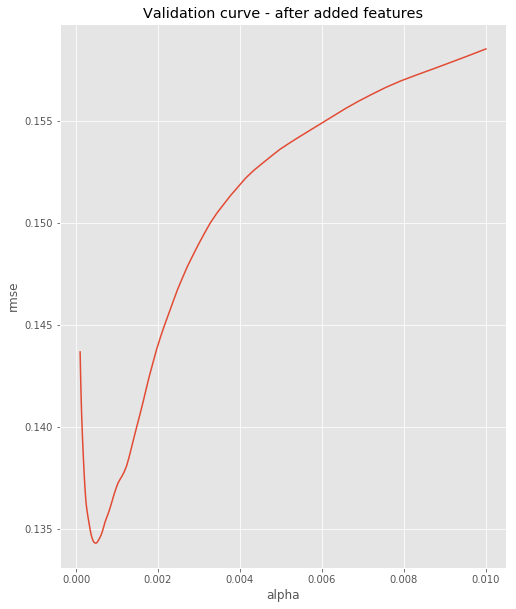

```python
cv_lasso_new2 = pd.Series(cv_lasso_new2, index = alphas_new2)
cv_lasso_new2.plot(title = "Validation curve - after added features")
plt.xlabel("alpha")
plt.ylabel("rmse")
```

```python
print(cv_lasso_new2.min(), cv_lasso_new2.idxmin())
```

```
0.1343216411873124 0.00048626015800653534
```

```python
model_lasso_new2 = Lasso(alpha = 0.000486,max_iter=10000)
model_lasso_new2.fit(X_new2_train,y_new2_train)
```

```
Lasso(alpha=0.000486, copy_X=True, fit_intercept=True, max_iter=10000,
   normalize=False, positive=False, precompute=False, random_state=None,
   selection='cyclic', tol=0.0001, warm_start=False)
```

```python
rmse_new2_cv(model_lasso_new2).mean()
```

```
0.13432159113170128
```

```python
coef_new2 = pd.Series(model_lasso_new2.coef_)
```

```python
print("Lasso picked " + str(sum(coef_new2 != 0)) + " variables and eliminated the other " +  str(sum(coef_new2 == 0)) + " variables")
```

```
Lasso picked 157 variables and eliminated the other 404 variables
```

```python
lasso_predict_new2 = model_lasso_new2.predict(X_new2_test)
```

```python
lasso_predict_new2_decode = np.expm1(lasso_predict_new2)
lasso_predict_new2_decode
```

```
array([125537.76571163, 163150.71677217, 190494.45200676, ...,
       175858.56428847, 121342.67865162, 227950.37755077])
```

```python
submission3 = pd.DataFrame({
        "Id": testdata['Id'],
        "SalePrice": lasso_predict_new2_decode
    })
submission3.to_csv('submission3.csv', index=False)
```

kaggle scores for lasso (new features added) is 0.12368

### 3.4.2 Gradient Boosting (new features added)

```python
def rmse_new2_cv(model):
    rmse_new2= np.sqrt(-cross_val_score(model, X_new2_train, y_new2_train, scoring="neg_mean_squared_error", cv = 5))
    return(rmse_new2)
```

```python
xg_new2_model = XGBRegressor(n_estimators=100, seed = 1234)
param_dict = {'max_depth': [2,3,4],
              'min_child_weight': [2,3,4],
              'learning_rate': [0.1,0.15,0.2],
              'gamma': [0.0, 0.1, 0.2]
}

grid_search_new2 = GridSearchCV(xg_new2_model, param_dict,cv=5)
grid_search_new2.fit(X_new2_train, y_new2_train)
display(grid_search_new2.best_params_)
```

```
{'gamma': 0.0, 'learning_rate': 0.15, 'max_depth': 3, 'min_child_weight': 3}
```

```python
xg_new2_model = XGBRegressor(n_estimators = 1000,
                        learning_rate = 0.15,
                        max_depth = 3,
                        min_child_weight = 3,
                        gamma = 0,
                        seed = 1234)
xg_new2_model.fit(X_new2_train, y_new2_train)
print("xgb_cross_validation: ",rmse_new2_cv(xg_new2_model).mean())
```

```
xgb_cross_validation:  0.1229538876973499
```

```python
xgb_predict_new2 = xg_new2_model.predict(X_new2_test)
```

```python
xgb_predict_new2_decode = np.expm1(xgb_predict_new2)
xgb_predict_new2_decode
```

```
array([128434.81, 158492.8 , 200358.12, ..., 165368.05, 113653.97,
       219930.23], dtype=float32)
```

```python
submission4 = pd.DataFrame({
        "Id": testdata['Id'],
        "SalePrice": xgb_predict_new2_decode
    })
submission4.to_csv('submission4.csv', index=False)
```

kaggle scores for gradient boosting (new features added) 0.14101

## 3.5 Ensemble two models

Ensemble two algorithm is considered to overcome overfitting/local optimal problem although lasso gives better prediction compared to gradient boosting. Ensemble method used in this report is using different weighting for two algorithms

```python
combination_1 = 0.75 * lasso_predict_new2_decode + 0.25 * xgb_predict_new2_decode
```

```python
# Create a new dataframe with only the columns Kaggle wants from the dataset.
submission5 = pd.DataFrame({
        "Id": testdata['Id'],
        "SalePrice": combination_1
    })
submission5.to_csv('submission5.csv', index=False)
```

kaggle scores 0.12349

```python
combination_2 = 0.65 * lasso_predict_new2_decode + 0.35 * xgb_predict_new2_decode
```

```python
# Create a new dataframe with only the columns Kaggle wants from the dataset.
submission6 = pd.DataFrame({
        "Id": testdata['Id'],
        "SalePrice": combination_2
    })
submission6.to_csv('submission6.csv', index=False)
```

kaggle scores 0.12430

```python
combination_3 = 0.70 * lasso_predict_new2_decode + 0.30 * xgb_predict_new2_decode
```

```python
# Create a new dataframe with only the columns Kaggle wants from the dataset.
submission7 = pd.DataFrame({
        "Id": testdata['Id'],
        "SalePrice": combination_3
    })
submission7.to_csv('submission7.csv', index=False)
```

kaggle scores 0.12383

```python
combination_4 = 0.80 * lasso_predict_new2_decode + 0.20 * xgb_predict_new2_decode
```

```python
# Create a new dataframe with only the columns Kaggle wants from the dataset.
submission8 = pd.DataFrame({
        "Id": testdata['Id'],
        "SalePrice": combination_4
    })
submission8.to_csv('submission8.csv', index=False)
```

kaggle scores 0.12327

```python
combination_5 = 0.85 * lasso_predict_new2_decode + 0.15 * xgb_predict_new2_decode
```

```python
# Create a new dataframe with only the columns Kaggle wants from the dataset.
submission9 = pd.DataFrame({
        "Id": testdata['Id'],
        "SalePrice": combination_5
    })
submission9.to_csv('submission9.csv', index=False)
```

kaggle scores 0.12318

```python
combination_6 = 0.90 * lasso_predict_new2_decode + 0.10 * xgb_predict_new2_decode
```

```python
# Create a new dataframe with only the columns Kaggle wants from the dataset.
submission10 = pd.DataFrame({
        "Id": testdata['Id'],
        "SalePrice": combination_6
    })
submission10.to_csv('submission10.csv', index=False)
```

kaggle scores 0.12322

The best combination is shown to be 85% weight of lasso and 15% gradient boosting, which gives the better score by Kaggle 0.12318 (top25%).

# 4 Short conclusion

In a conclusion, lasso and gradient boosting can give a good prediction for sale price although accuracy is not extremely high. When ensemble two models, best combination is tested to be 85% lasso and 15% gradient boosting. In addition, important features are highlighted in this report. Although GrLivArea (above ground living area square feet), Overall Quality and Overall Condition are already accepted as importance features by the public, some features such as GarageArea and TotalBsmtSF (total square feet of basement area) may not considered as important feature in daily life but play important roles in sale price prediction. Hence, these highlighted features should be considered when evaluate a house price whether for individual buyers or real estate investors.

If more related features such as interest rate, local salary/income, population and property tax are available, it will be very useful for local house price prediction. In terms of regression model, there are still lots of techniques can be conducted for regression task. Ensemble several regression model would give better prediction results.